# Energy Use Intensity

**Data Science side project**

*All rights reserved by Thaiprayoon N.*

# Table of Contents

## Import data

This data set comes from **[Kaggle.com](https://www.kaggle.com/)** There are Building simulation results from for than 250k EnergyPlus simulations. With 48 columns of important data for using analytics energy consumption of building comsumtion following.

- Building Type
- Floor to floor height
- Number of floors (Total Area / Floor Area)
- Height (Number of floors * Floor to floor height)
- Wall R value
- Roof R value
- Window U value
- etc.

**Universal Design Space Exploration**

Design Space Exploration (DSE) analysis techniques represent a data-centric approach to integrating performance analysis in early design phases when there is the greatest potential to cheaply improve the energy efficiency of a building. We focus on a novel extension of DSE called Universal Design Space Exploration (UDSE), which leverages massive databases of pre-simulated analysis that represent all possible outcomes of common analysis workflows. These databases, called Design Spaces, become “universal” when a single pre-simulated design space can be re-applied to future, unknown projects. Unlike current simulation methods, which require a design to exist before it can be analyzed and often take minutes or hours to simulate, UDSE leverages pre-simulation to deliver rapid and relevant insight as new designs are conceptualized. The data underpinning UDSE enables advanced statistical and Artificial Intelligence methods, allowing UDSE to deliver a greater understanding of the larger problem being explored rather than simply delivering analysis of several pre-conceived design options. We believe that UDSE can provide instantaneous, relevant analysis for all building design projects at negligible cost.

**AutoBEM**

Oak Ridge National Laboratory has developed a collection of software and algorithms, collectively referred to as “Automatic Building Energy Modeling” (AutoBEM), which allows building energy modeling of each building at large geographic scales (AutoBEM). Within AutoBEM, building properties are detected, inferred, or predicted as inputs to generate building energy models using OpenStudio and simulate these buildings using EnergyPlus. OpenStudio is a collection of software tools to support energy modeling in EnergyPlus, which is a physical building energy simulation engine [(OpenStudio)](https://openstudio.net) [(EnergyPlus)](https://energyplus.net).

**[See more on Kaggle](https://www.kaggle.com/petermcnallysg/universal-design-space-building-energy-simulation)**

```python
import pandas as pd

data0 = pd.read_csv("Universal_Design_Space_Building_Energy_Simulation_input_output.csv",low_memory=False)
data0.info()
```

```
<class 'pandas.core.frame.DataFrame'>
RangeIndex: 260748 entries, 0 to 260747
Data columns (total 49 columns):
 #   Column                                 Non-Null Count   Dtype
---  ------                                 --------------   -----
 0   ID                                     260748 non-null  object
 1   BuildingType                           260748 non-null  object
 2   ClimateZone                            260748 non-null  object
 3   TotalArea                              260748 non-null  int64
 4   TotalArea_Setting                      260748 non-null  object
 5   FloorArea                              260748 non-null  int64
 6   FloorArea_Setting                      260748 non-null  object
 7   NumFloors                              260748 non-null  int64
 8   PlateDepth                             260748 non-null  int64
 9   PlateDepth_Setting                     260748 non-null  object
```

[output cut: 41 more lines]

```python
data = data0.copy()
data.describe()
```

|  | TotalArea | FloorArea | NumFloors | PlateDepth | PlateLength | FloorHeight | Height | WWR | Wall_R_Value | Roof_R_Value | ... | Heating_Electricity_kBTU_per_sf | Heating_NaturalGas_kBTU_per_sf | Heating_Total_kBTU_per_sf | WaterSystems_Electricity_kBTU_per_sf | Lighting_Electricity_kBTU_per_sf | Equipment_Electricity_kBTU_per_sf | Fans_Electricity_kBTU_per_sf | Pumps_Electricity_kBTU_per_sf | HeatRejection_Electricity_kBTU_per_sf | HeatRecovery_Electricity_kBTU_per_sf |
| --- | --- | --- | --- | --- | --- | --- | --- | --- | --- | --- | --- | --- | --- | --- | --- | --- | --- | --- | --- | --- | --- |
| count | 2.607480e+05 | 260748.000000 | 260748.000000 | 260748.000000 | 260748.000000 | 260748.000000 | 260748.000000 | 260748.000000 | 260748.000000 | 260748.000000 | ... | 260748.000000 | 260748.000000 | 260748.000000 | 260748.0 | 260748.000000 | 260748.000000 | 260748.000000 | 260748.000000 | 260748.000000 | 260748.000000 |
| mean | 1.994595e+05 | 25846.604507 | 8.866783 | 97.235906 | 209.707273 | 14.602774 | 129.436559 | 59.377107 | 22.190043 | 41.705422 | ... | 0.537301 | 43.137857 | 43.675158 | 0.0 | 8.084788 | 38.817513 | 22.115252 | 2.509235 | 0.395789 | 4.833672 |
| std | 2.156952e+05 | 10350.688871 | 10.753368 | 25.367408 | 76.845830 | 1.970821 | 161.182146 | 17.593025 | 7.072464 | 14.076231 | ... | 1.728176 | 97.983243 | 97.762052 | 0.0 | 4.609707 | 15.903090 | 32.499733 | 4.598613 | 1.391958 | 10.479290 |
| min | 3.994400e+04 | 14519.000000 | 1.000000 | 45.000000 | 129.000000 | 10.000000 | 13.000000 | 25.000000 | 8.330000 | 21.340000 | ... | 0.000000 | 0.000000 | 0.000000 | 0.0 | 0.648153 | 11.218701 | 0.180277 | 0.000000 | 0.000000 | 0.000000 |
| 25% | 1.016330e+05 | 14971.000000 | 4.000000 | 75.000000 | 140.000000 | 13.000000 | 52.000000 | 50.390625 | 16.330000 | 31.340000 | ... | 0.000000 | 0.000000 | 0.232082 | 0.0 | 4.537323 | 24.806507 | 2.727917 | 0.016485 | 0.000000 | 0.000000 |
| 50% | 1.497120e+05 | 24998.000000 | 6.000000 | 98.000000 | 197.000000 | 15.000000 | 85.000000 | 61.742424 | 20.330000 | 31.340000 | ... | 0.000000 | 0.688570 | 1.768745 | 0.0 | 7.506889 | 41.608445 | 7.107739 | 1.186714 | 0.000000 | 0.084560 |
| 75% | 2.018510e+05 | 39539.000000 | 10.000000 | 122.000000 | 238.000000 | 16.000000 | 135.000000 | 71.228070 | 30.000000 | 60.000000 | ... | 0.071649 | 8.487569 | 9.333217 | 0.0 | 10.513514 | 52.364630 | 15.606273 | 2.963894 | 0.229866 | 1.419913 |
| max | 1.009256e+06 | 40434.000000 | 67.000000 | 153.000000 | 404.000000 | 18.000000 | 1072.000000 | 89.910314 | 30.000000 | 60.000000 | ... | 39.978431 | 583.250051 | 583.250051 | 0.0 | 19.497817 | 68.665014 | 103.441310 | 34.478568 | 15.186499 | 33.107724 |

8 rows × 31 columns

```python
data.head()
```

|  | ID | BuildingType | ClimateZone | TotalArea | TotalArea_Setting | FloorArea | FloorArea_Setting | NumFloors | PlateDepth | PlateDepth_Setting | ... | Heating_Electricity_kBTU_per_sf | Heating_NaturalGas_kBTU_per_sf | Heating_Total_kBTU_per_sf | WaterSystems_Electricity_kBTU_per_sf | Lighting_Electricity_kBTU_per_sf | Equipment_Electricity_kBTU_per_sf | Fans_Electricity_kBTU_per_sf | Pumps_Electricity_kBTU_per_sf | HeatRejection_Electricity_kBTU_per_sf | HeatRecovery_Electricity_kBTU_per_sf |
| --- | --- | --- | --- | --- | --- | --- | --- | --- | --- | --- | --- | --- | --- | --- | --- | --- | --- | --- | --- | --- | --- |
| 0 | College_1A_100000_14286_120_13_25_20_25_BaseLi... | College | 1A | 101793 | low | 14542 | low | 7 | 122 | high | ... | 0.083671 | 0.0 | 0.083671 | 0.0 | 10.209886 | 44.423582 | 5.378116 | 4.748715 | 0.0 | 3.704229 |
| 1 | College_1A_100000_14286_120_13_25_20_25_BaseLi... | College | 1A | 101793 | low | 14542 | low | 7 | 122 | high | ... | 0.083671 | 0.0 | 0.083671 | 0.0 | 10.209886 | 44.423582 | 3.689256 | 4.675590 | 0.0 | 3.647120 |
| 2 | College_1A_100000_14286_120_13_25_20_25_BaseLi... | College | 1A | 101793 | low | 14542 | low | 7 | 122 | high | ... | 0.083856 | 0.0 | 0.083856 | 0.0 | 10.209886 | 44.423582 | 5.725152 | 4.350329 | 0.0 | 3.657521 |
| 3 | College_1A_100000_14286_120_13_25_20_25_BaseLi... | College | 1A | 101793 | low | 14542 | low | 7 | 122 | high | ... | 0.083856 | 0.0 | 0.083856 | 0.0 | 10.209886 | 44.423582 | 3.751486 | 4.224587 | 0.0 | 3.551803 |
| 4 | College_1A_100000_14286_120_13_25_20_25_BaseLi... | College | 1A | 101793 | low | 14542 | low | 7 | 122 | high | ... | 0.062975 | 0.0 | 0.062975 | 0.0 | 10.209886 | 44.423582 | 4.730901 | 4.131386 | 0.0 | 3.586181 |

5 rows × 49 columns

### Check values in each columns

```python
data.columns
```

```
Index(['ID', 'BuildingType', 'ClimateZone', 'TotalArea', 'TotalArea_Setting',
       'FloorArea', 'FloorArea_Setting', 'NumFloors', 'PlateDepth',
       'PlateDepth_Setting', 'PlateLength', 'FloorHeight',
       'FloorHeight_Setting', 'Height', 'WWR', 'WWR_surfaces', 'SolarDesign',
       'Standard', 'HVAC', 'HVAC_Setting', 'EnvelopeQuality_Setting',
       'Wall_R_Value', 'Roof_R_Value', 'Glass_and_Frame_U_Value', 'SHGC',
       'LPD_Adjustment', 'LPD_Adjustment_Setting',
       'Interior_Lights_Final_W_per_sf', 'Exterior_Lights_Final_1_W',
       'Exterior_Lights_Final_2_W', 'Setpoint_Setting', 'HeatingCoil',
       'COP_Efficiency_Heating', 'CoolingCoil', 'COP_Efficiency_Cooling',
       'EUI_kBTU_per_sf', 'Electricity_Facility_kBTU_per_sf',
       'NaturalGas_Facility_kBTU_per_sf', 'Cooling_Electricity_kBTU_per_sf',
       'Heating_Electricity_kBTU_per_sf', 'Heating_NaturalGas_kBTU_per_sf',
       'Heating_Total_kBTU_per_sf', 'WaterSystems_Electricity_kBTU_per_sf',
       'Lighting_Electricity_kBTU_per_sf', 'Equipment_Electricity_kBTU_per_sf',
       'Fans_Electricity_kBTU_per_sf', 'Pumps_Electricity_kBTU_per_sf',
       'HeatRejection_Electricity_kBTU_per_sf',
       'HeatRecovery_Electricity_kBTU_per_sf'],
      dtype='object')
```

```python
# Check unique values
# col = [i for i in data.columns]
# for i in col:
#     print(i,"---> \n",data[i].unique(),"\n")
```

```python
data = data.drop(columns=["TotalArea_Setting","FloorArea_Setting","PlateDepth_Setting",
                          "FloorHeight_Setting","WWR_surfaces","Standard","HVAC",
                          "WaterSystems_Electricity_kBTU_per_sf","LPD_Adjustment",
                          "Setpoint_Setting"])
```

## EDA and Data preparation.

**EDA: Exploratory Data Analysis**

### Cut off the outlier

```python
# Changing Dtype object to category to numeric

df2 = data.copy()
g = df2.columns.to_series().groupby(df2.dtypes).groups
a = {k.name: v for k, v in g.items()}
obls = []
flols = []
intls = []
for i in a['object']:
    obls.append(i)
for i in a['float64']:
    flols.append(i)
for i in a['int64']:
    intls.append(i)
```

#### Plot some column to explore outlier

```
(array([ 1,  2,  3,  4,  5,  6,  7,  8,  9, 10, 11, 12, 13, 14, 15, 16, 17,
        18, 19, 20, 21, 22, 23, 24, 25, 26, 27, 28, 29]),
 [Text(1, 0, 'TotalArea'),
```

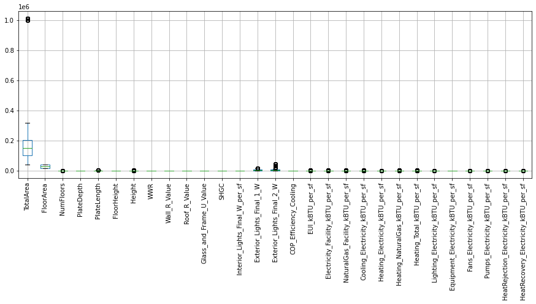

```python
import matplotlib.pyplot as plt
plt.figure(figsize=(15,5))

data.boxplot()
plt.xticks(rotation = 90)
```

```
(array([1, 2]),
 [Text(1, 0, 'Exterior_Lights_Final_1_W'),
```

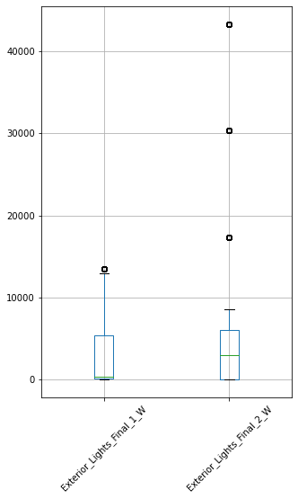

```python
plt.figure(figsize=(5,8))
data[['Exterior_Lights_Final_1_W','Exterior_Lights_Final_2_W']].boxplot()
plt.xticks(rotation = 45)
```

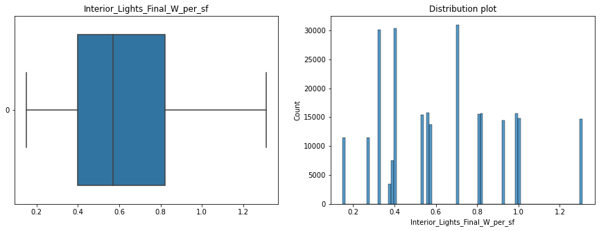

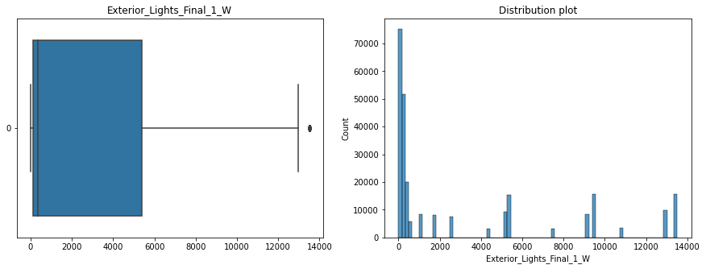

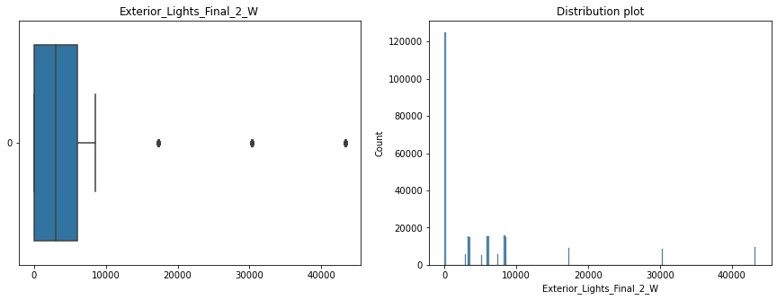

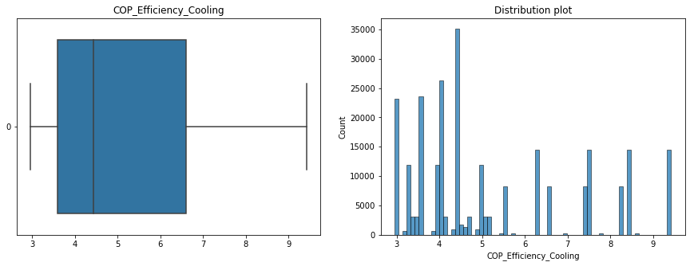

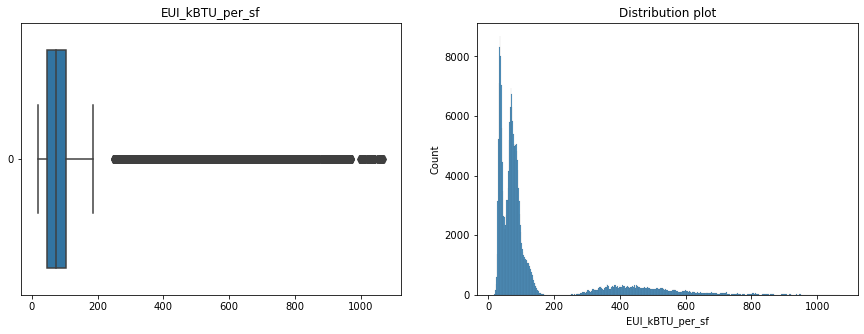

```python
import seaborn as sns
import matplotlib.pyplot as plt

for i in flols[5:10]:
    fig, ax = plt.subplots(1, 2,figsize=(15,5))

    ax[0].set_title(i)
    ax[1].set_title('Distribution plot')
    plt.show
    sns.boxplot(ax=ax[0], data=data[i], orient='h')
    sns.histplot(ax=ax[1], data=data[i])
```

#### IQR (Interquartile Range)

$$Interquartile\ Range = Q_{3} - Q_{1}$$

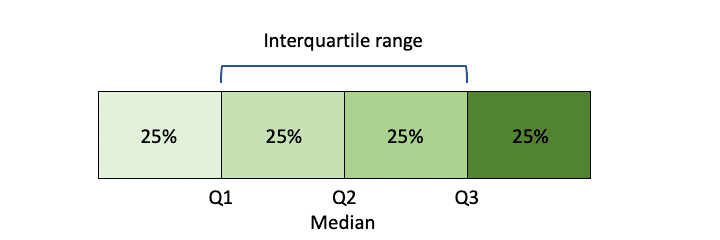

```python
# import seaborn as sns
# import matplotlib.pyplot as plt

# for i in flols:
#     fig, ax = plt.subplots(1, 2,figsize=(15,5))

#     ax[0].set_title('Boxplot')
#     ax[1].set_title('Distribution plot')

#     sns.boxplot(ax=ax[0], data=data[i], orient='h')
#     sns.histplot(ax=ax[1], data=data[i])
```

```python
dfiqr = data.copy()

for i in intls:
    dfiqr = dfiqr.drop(columns=[i])
for j in obls:
    dfiqr = dfiqr.drop(columns=[j])
```

```python
#q1,q3 =np.percentile(data,[25,75], axis=0)
tmp = dfiqr.quantile(([0.25,0.75]))
# print(tmp)
q1 = tmp.iloc[0,:]
q3 = tmp.iloc[1,:]
```

```python
IQR = q3-q1
# print("IQR\n",IQR)
upper = q3+1.5*IQR
lower = q1-1.5*IQR
# print("The largest value in the data set \n",upper)
# print("The smallest value in the data set \n",lower)
```

```python
# Find index to drop
result = dfiqr[((dfiqr>upper).any(axis = 1)) | ((dfiqr<lower).any(axis = 1))].index
result
```

```
Int64Index([     0,      1,      2,      3,      4,      5,      6,      7,
                 8,      9,
            ...
            260738, 260739, 260740, 260741, 260742, 260743, 260744, 260745,
            260746, 260747],
           dtype='int64', length=158695)
```

```python
dfiqr["ID"] = data["ID"]
dfiqrnew = dfiqr.drop(index=result)
```

```python
dfiqrnew.head()
```

|  | WWR | Wall_R_Value | Roof_R_Value | Glass_and_Frame_U_Value | SHGC | Interior_Lights_Final_W_per_sf | Exterior_Lights_Final_1_W | Exterior_Lights_Final_2_W | COP_Efficiency_Cooling | EUI_kBTU_per_sf | ... | Heating_Electricity_kBTU_per_sf | Heating_NaturalGas_kBTU_per_sf | Heating_Total_kBTU_per_sf | Lighting_Electricity_kBTU_per_sf | Equipment_Electricity_kBTU_per_sf | Fans_Electricity_kBTU_per_sf | Pumps_Electricity_kBTU_per_sf | HeatRejection_Electricity_kBTU_per_sf | HeatRecovery_Electricity_kBTU_per_sf | ID |
| --- | --- | --- | --- | --- | --- | --- | --- | --- | --- | --- | --- | --- | --- | --- | --- | --- | --- | --- | --- | --- | --- |
| 11 | 25.000000 | 30.00 | 60.00 | 0.20 | 0.25 | 1.0 | 441.80 | 8552.0 | 3.552525 | 94.998433 | ... | 0.050334 | 0.0 | 0.050334 | 10.209886 | 44.423582 | 3.296442 | 3.845008 | 0.0 | 3.337595 | College_1A_100000_14286_120_13_25_20_25_BaseLi... |
| 17 | 25.000000 | 30.00 | 60.00 | 0.20 | 0.25 | 1.0 | 441.80 | 8552.0 | 3.996591 | 89.394823 | ... | 0.040897 | 0.0 | 0.040897 | 10.209886 | 44.423582 | 3.296442 | 3.845008 | 0.0 | 3.337595 | College_1A_100000_14286_120_13_25_20_25_BaseLi... |
| 23 | 25.000000 | 30.00 | 60.00 | 0.20 | 0.25 | 1.0 | 441.80 | 8552.0 | 4.440657 | 83.791214 | ... | 0.031459 | 0.0 | 0.031459 | 10.209886 | 44.423582 | 3.296442 | 3.845008 | 0.0 | 3.337595 | College_1A_100000_14286_120_13_25_20_25_BaseLi... |
| 29 | 25.000000 | 8.33 | 21.34 | 0.66 | 0.25 | 0.4 | 176.72 | 3420.8 | 2.960438 | 94.982676 | ... | 0.135453 | 0.0 | 0.135453 | 4.083955 | 44.423582 | 3.185673 | 3.685125 | 0.0 | 3.213624 | College_1A_100000_14286_120_13_25_66_25_BestLi... |
| 31 | 74.152542 | 8.33 | 21.34 | 0.66 | 0.25 | 0.4 | 176.72 | 3420.8 | 3.552525 | 93.761766 | ... | 0.172216 | 0.0 | 0.172216 | 4.083955 | 44.423582 | 3.352672 | 4.427529 | 0.0 | 3.426734 | College_1A_100000_14286_120_13_25_66_25_BestLi... |

5 rows × 23 columns

### Min-Max Normalization

```python
dfiqrnew2 = dfiqrnew.copy()
for i in flols:
    mu = dfiqrnew[i].mean()
    sd = dfiqrnew[i].std()
#     print(mu, sd)

    max = dfiqrnew[i].max()
    min = dfiqrnew[i].min()
#     print(max, min)

#     dfiqrnew[i] = dfiqrnew[i].apply(lambda x:(x-mu)/sd)
    dfiqrnew2[i] = dfiqrnew[i].apply(lambda x:(x-min)/(max-min))
#df['size'] = df['size'].apply(lambda x:(x-mu)/sd if sd!=0 else x)
dfiqrnew2.head()
```

|  | WWR | Wall_R_Value | Roof_R_Value | Glass_and_Frame_U_Value | SHGC | Interior_Lights_Final_W_per_sf | Exterior_Lights_Final_1_W | Exterior_Lights_Final_2_W | COP_Efficiency_Cooling | EUI_kBTU_per_sf | ... | Heating_Electricity_kBTU_per_sf | Heating_NaturalGas_kBTU_per_sf | Heating_Total_kBTU_per_sf | Lighting_Electricity_kBTU_per_sf | Equipment_Electricity_kBTU_per_sf | Fans_Electricity_kBTU_per_sf | Pumps_Electricity_kBTU_per_sf | HeatRejection_Electricity_kBTU_per_sf | HeatRecovery_Electricity_kBTU_per_sf | ID |
| --- | --- | --- | --- | --- | --- | --- | --- | --- | --- | --- | --- | --- | --- | --- | --- | --- | --- | --- | --- | --- | --- |
| 11 | 0.000000 | 1.0 | 1.0 | 0.0 | 0.0 | 1.000000 | 0.034954 | 1.0 | 0.091653 | 0.582000 | ... | 0.281023 | 0.0 | 0.002372 | 0.646387 | 0.578016 | 0.086309 | 0.723544 | 0.0 | 0.940548 | College_1A_100000_14286_120_13_25_20_25_BaseLi... |
| 17 | 0.000000 | 1.0 | 1.0 | 0.0 | 0.0 | 1.000000 | 0.034954 | 1.0 | 0.160393 | 0.537886 | ... | 0.228331 | 0.0 | 0.001927 | 0.646387 | 0.578016 | 0.086309 | 0.723544 | 0.0 | 0.940548 | College_1A_100000_14286_120_13_25_20_25_BaseLi... |
| 23 | 0.000000 | 1.0 | 1.0 | 0.0 | 0.0 | 1.000000 | 0.034954 | 1.0 | 0.229133 | 0.493772 | ... | 0.175639 | 0.0 | 0.001483 | 0.646387 | 0.578016 | 0.086309 | 0.723544 | 0.0 | 0.940548 | College_1A_100000_14286_120_13_25_20_25_BaseLi... |
| 29 | 0.000000 | 0.0 | 0.0 | 1.0 | 0.0 | 0.294118 | 0.010065 | 0.4 | 0.000000 | 0.581876 | ... | 0.756249 | 0.0 | 0.006384 | 0.232265 | 0.578016 | 0.083109 | 0.693458 | 0.0 | 0.905612 | College_1A_100000_14286_120_13_25_66_25_BestLi... |
| 31 | 0.757238 | 0.0 | 0.0 | 1.0 | 0.0 | 0.294118 | 0.010065 | 0.4 | 0.091653 | 0.572265 | ... | 0.961502 | 0.0 | 0.008116 | 0.232265 | 0.578016 | 0.087934 | 0.833161 | 0.0 | 0.965667 | College_1A_100000_14286_120_13_25_66_25_BestLi... |

5 rows × 23 columns

```python
data2 = data.copy()

for i in flols:
    data2 = data2.drop(columns=[i])

dfn = pd.merge(data2,dfiqrnew2, on = "ID",how = "inner")
dfn.head()
```

|  | ID | BuildingType | ClimateZone | TotalArea | FloorArea | NumFloors | PlateDepth | PlateLength | FloorHeight | Height | ... | Cooling_Electricity_kBTU_per_sf | Heating_Electricity_kBTU_per_sf | Heating_NaturalGas_kBTU_per_sf | Heating_Total_kBTU_per_sf | Lighting_Electricity_kBTU_per_sf | Equipment_Electricity_kBTU_per_sf | Fans_Electricity_kBTU_per_sf | Pumps_Electricity_kBTU_per_sf | HeatRejection_Electricity_kBTU_per_sf | HeatRecovery_Electricity_kBTU_per_sf |
| --- | --- | --- | --- | --- | --- | --- | --- | --- | --- | --- | --- | --- | --- | --- | --- | --- | --- | --- | --- | --- | --- |
| 0 | College_1A_100000_14286_120_13_25_20_25_BaseLi... | College | 1A | 101793 | 14542 | 7 | 122 | 350 | 13 | 91 | ... | 0.821321 | 0.281023 | 0.0 | 0.002372 | 0.646387 | 0.578016 | 0.086309 | 0.723544 | 0.0 | 0.940548 |
| 1 | College_1A_100000_14286_120_13_25_20_25_BaseLi... | College | 1A | 101793 | 14542 | 7 | 122 | 350 | 13 | 91 | ... | 0.667235 | 0.228331 | 0.0 | 0.001927 | 0.646387 | 0.578016 | 0.086309 | 0.723544 | 0.0 | 0.940548 |
| 2 | College_1A_100000_14286_120_13_25_20_25_BaseLi... | College | 1A | 101793 | 14542 | 7 | 122 | 350 | 13 | 91 | ... | 0.513149 | 0.175639 | 0.0 | 0.001483 | 0.646387 | 0.578016 | 0.086309 | 0.723544 | 0.0 | 0.940548 |
| 3 | College_1A_100000_14286_120_13_25_66_25_BestLi... | College | 1A | 101793 | 14542 | 7 | 122 | 350 | 13 | 91 | ... | 0.998144 | 0.756249 | 0.0 | 0.006384 | 0.232265 | 0.578016 | 0.083109 | 0.693458 | 0.0 | 0.905612 |
| 4 | College_1A_100000_14286_120_13_25_66_25_BestLi... | College | 1A | 101793 | 14542 | 7 | 122 | 350 | 13 | 91 | ... | 0.932584 | 0.961502 | 0.0 | 0.008116 | 0.232265 | 0.578016 | 0.087934 | 0.833161 | 0.0 | 0.965667 |

5 rows × 39 columns

```python
# Convert Dtype object to category to numeric
df2 = dfn.copy()

for i in obls:
    df2[i] = pd.Categorical(df2[i])
    df2[i] = df2[i].cat.codes
# df2.info()
```

```python
# Convert to float
from sklearn.preprocessing import LabelEncoder

col = df2.columns
le = LabelEncoder()
for i in col:
    df2[i] = df2[i].astype('float')
df2.info()
```

```
<class 'pandas.core.frame.DataFrame'>
Int64Index: 102053 entries, 0 to 102052
Data columns (total 39 columns):
 #   Column                                 Non-Null Count   Dtype
---  ------                                 --------------   -----
 0   ID                                     102053 non-null  float64
 1   BuildingType                           102053 non-null  float64
 2   ClimateZone                            102053 non-null  float64
 3   TotalArea                              102053 non-null  float64
 4   FloorArea                              102053 non-null  float64
 5   NumFloors                              102053 non-null  float64
 6   PlateDepth                             102053 non-null  float64
 7   PlateLength                            102053 non-null  float64
 8   FloorHeight                            102053 non-null  float64
 9   Height                                 102053 non-null  float64
```

[output cut: 31 more lines]

#### Heat map plot to show the data correlation

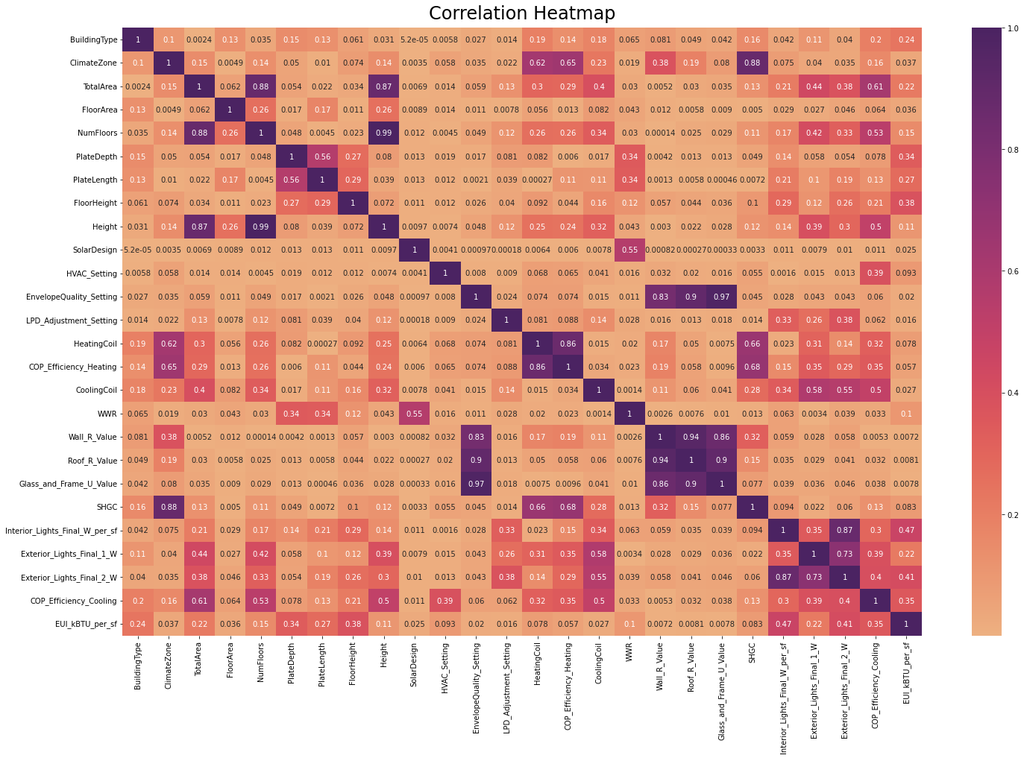

```python
import matplotlib.pyplot as plt
import seaborn as sns
plt.figure(figsize=(24, 15))


data2 = df2.copy()
data2 = data2.iloc[:,1:27]
col = data2.columns
corr_sp = data2[col].corr(method='pearson')
# plot correlation
sns.heatmap(abs(corr_sp), annot=True, cmap="flare") # summer_r
plt.title('Correlation Heatmap', fontdict={'fontsize':24}, pad=12)
plt.show()
```

## Predict by using XGboost

```python
import xgboost as xgb
from sklearn.metrics import mean_absolute_error
from sklearn.model_selection import train_test_split
import pandas as pd
import numpy as np

dfnew = df2.copy()
X, y = dfnew.iloc[:,1:26],dfnew.iloc[:,-13]
data_dmatrix = xgb.DMatrix(data=X,label=y)

X_train, X_test, y_train, y_test = train_test_split(X, y, test_size=0.3, random_state=999)

xg_reg = xgb.XGBRegressor(objective ='reg:squarederror', colsample_bytree = 0.3, learning_rate = 0.1,
                max_depth = 5, alpha = 10, n_estimators = 10)

xg_reg.fit(X_train,y_train)

preds = xg_reg.predict(X_test)


# reverse score
# mu = dfiqrnew['EUI_kBTU_per_sf'].mean()

max1 = dfiqrnew['EUI_kBTU_per_sf'].max()
min1 = dfiqrnew['EUI_kBTU_per_sf'].min()

y_test_new = (y_test*(max1-min1)) + min1
preds_new = (preds*(max1-min1)) + min1

print("Mean Absolute Error: ",mean_absolute_error(y_test_new, preds_new))
```

```
Mean Absolute Error:  9.72474943313263
```

### Show some of the predicted data

```python
X_test2 = X_test.copy()
X_test2['PREDICT'] = preds_new
X_test2['REAL DATA'] = data['EUI_kBTU_per_sf']
X_test2['ERROR'] = abs(X_test2['PREDICT'] - X_test2['REAL DATA'])

X_test2.iloc[:5,-3:]
```

[output not shown]

### Mean Absolute Error

**MAE: Mean Absolute Error**

[figure not shown]

**[Source: wikipedia.org](https://en.wikipedia.org/wiki/Mean_absolute_error)**

### Show the first predicted data and MAE

```python
print("Real data: ",data.iloc[36048]['EUI_kBTU_per_sf'])
print("Predict: ",X_test2.iloc[0]['PREDICT'])
print("Mean Absolute Error: ",mean_absolute_error(y_test_new, preds_new))
```

[output not shown]

### 3D Scatter Plot of Predict datas Vs Real data Vs Error

```python
df3 = y_test_new.to_frame()
df3 = df3.reset_index()

df3new = df3.drop(columns=["index"])
df3new['preds'] = preds_new
df3new['Error'] = abs(df3new['EUI_kBTU_per_sf'] - df3new['preds'])
```

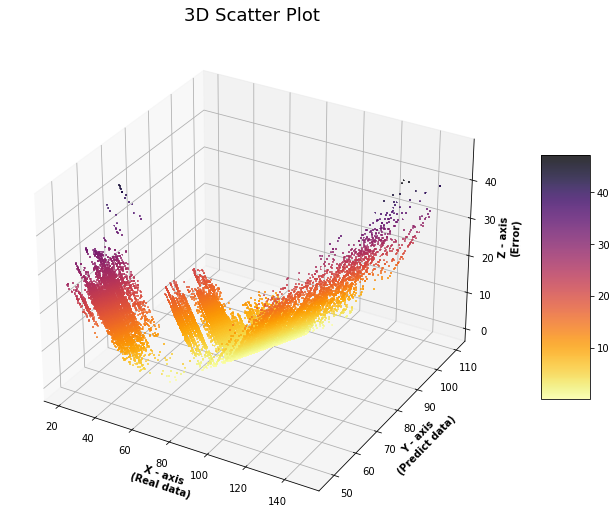

```python
from mpl_toolkits import mplot3d
import numpy as np
import matplotlib.pyplot as plt


x = df3new['EUI_kBTU_per_sf']
y = df3new['preds']
z = df3new['Error']


fig = plt.figure(figsize = (16, 9))
ax = plt.axes(projection ="3d")


ax.grid(b = True, color ='grey',
        linestyle ='-.', linewidth = 0.3,
        alpha = 0.2)


my_cmap = plt.get_cmap('inferno_r')


sctt = ax.scatter3D(x, y, z,
                    alpha = 0.8,
                    c = z,
                    cmap = my_cmap,
                    marker ='+',s=3)

plt.title("3D Scatter Plot", fontdict={'fontsize':18}, pad=12)
ax.set_xlabel('X - axis\n(Real data)', fontweight ='bold')
ax.set_ylabel('Y - axis\n(Predict data)', fontweight ='bold')
ax.set_zlabel('Z - axis\n(Error)', fontweight ='bold')
fig.colorbar(sctt, ax = ax, shrink = 0.5, aspect = 5)

plt.show()
```

### Line Plot of Predict datas, Real data, and Error with 100 observations

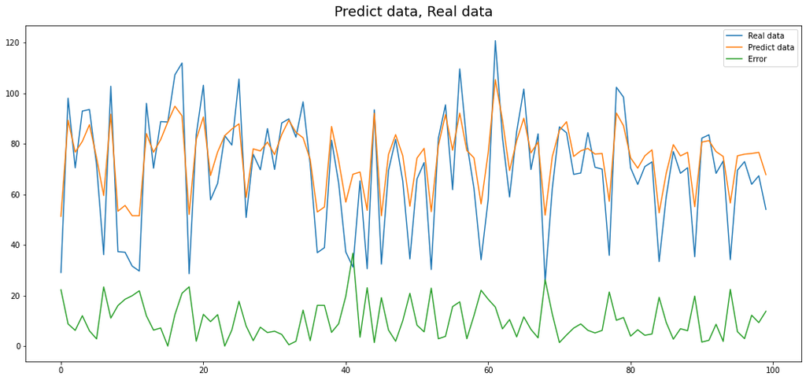

```python
plt.figure(figsize=(18,8))
# plt.plot(df3new.iloc[:100])
a = df3new.iloc[:100,0]
b = df3new.iloc[:100,1]
c = df3new.iloc[:100,2]
plt.plot(a, label ="Real data")
plt.plot(b, label ="Predict data")
plt.plot(c, label ="Error")
plt.title("Predict data, Real data", fontdict={'fontsize':18}, pad=12)

plt.legend(loc ="upper right")
plt.show()
```

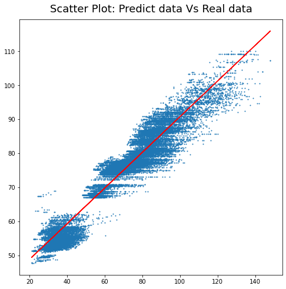

```python
import matplotlib.pyplot as plt
plt.figure(figsize=(8, 8))


x = df3new['EUI_kBTU_per_sf']
y = df3new['preds']
y = y.astype("float64")
plt.scatter(x, y, s= 1)

m, b = np.polyfit(x, y, 1)
plt.title("Scatter Plot: Predict data Vs Real data", fontdict={'fontsize':18}, pad=12)

plt.plot(x, m*x + b ,c = "red")
plt.show()
```